# Business Statistics End of Term Assessment IB94X0 2024-2025 #1 / Student-ID: 5650766

## Declarations for Assessed University Assignments

**Academic Integrity Declaration**

We’re part of an academic community at Warwick. Whether studying, teaching, or researching, we’re all taking part in an expert conversation which must meet standards of academic integrity. When we all meet these standards, we can take pride in our own academic achievements, as individuals and as an academic community.

Academic integrity means committing to honesty in academic work, giving credit where we’ve used others’ ideas and being proud of our own achievements.

In submitting my work, I confirm that:

- I have read the guidance on academic integrity provided in the Student Handbook and understand the University regulations in relation to Academic Integrity. I am aware of the potential consequences of Academic Misconduct.
- I declare that this work is entirely my own, except where I have stated otherwise.
- No substantial part(s) of the work submitted here has also been submitted by me in other credit bearing assessments courses of study (other than in certain cases of a resubmission of a piece of work), and I acknowledge that if this has been done this may lead to an appropriate sanction.
- Where a generative Artificial Intelligence such as ChatGPT has been used I confirm I have abided by both the University guidance and specific requirements as set out in the Student Handbook and the Assessment brief. I have clearly acknowledged the use of any generative Artificial Intelligence in my submission, my reasoning for using it and which generative AI (or AIs) I have used. Except where indicated the work is otherwise entirely my own.
- I understand that should this piece of work raise concerns requiring investigation in relation to any of points above, it is possible that other work I have submitted for assessment will be checked, even if marks (provisional or confirmed) have been published.
- Where a proof-reader, paid or unpaid was used, I confirm that the proof-reader was made aware of and has complied with the University’s proofreading policy.

**Declaration of independence and use of AI and other tools:**

This is to certify that the work I am submitting is my own. All external references and sources are clearly acknowledged and identified within the contents. I am aware of the University of Warwick regulation concerning plagiarism and collusion.

No substantial part(s) of the work submitted here has also been submitted by me in other assessments for accredited courses of study, and I acknowledge that if this has been done an appropriate reduction in the mark I might otherwise have received will be made.

AI was used in the preparation of this work. It was used in the development of the code: It was used to provide example uses of functions or approaches to elements of the challenges which were then checked, interpreted and modified by me to be applicable to this data/report.

Additionally, translation and paraphrasing tools were used to help to improve the given English answers or to translate some words from german to english.

## Pre-work

```r
# Load libraries
library(tidyverse)
library(ggplot2)
library(emmeans)
library(gridExtra); library(grid) # For displaying graphics in grids
library(ggcorrplot) # For correlation matrix visualisation
library(Hmisc) # For correlation analysis
library(car) # To calculate the Variance Inflation Factor (VIF)

# Set output width
options(width=100)

# Deactivate the scientific number notation
options(scipen = 999)

# Set the working directory
setwd("C:/Users/daves/OneDrive/Desktop/University of Warwick/Term 1/Business Statistics/Assignment 2")
```

# Question 1 – Cardio Vascular Disease in England

The code below performs the following analyses as required:

- Identify which of the given factors (overweight, smokers, wellbeing and poverty) has the strongest influence on the prevalence of CVD
- Graphical visualisation of the effect of poverty upon CVD

## Data dictionary

The data used for the following analyses originates from various datasets from the UK Office for National Statistics. Each row in the dataset represents one local authority region within the UK and displays the percentage of people who have recently suffered from cardiovascular disease (CVD) in that area.

The dataset variables are described in the following table:

| Variable | Description |
| --- | --- |
| area_name | Name of the local authority region |
| area_code | Unique identifier code for the local authority region |
| Population | Total population living in the local authority region |
| Poverty | Proportion (%) of people in the area who meet the definition of living in poverty |
| CVD | Proportion (%) of people in the area who have recently experienced cardiovascular disease (CVD) |
| overweight | Proportion (%) of people in the area who are classified as overweight |
| smokers | Proportion (%) of people in the area who smoke |
| wellbeing | Average wellbeing score of people living in the area |

## Data import and overview

```r
cvd_data <- read_csv("Cardio_Vascular_Disease.csv")
head(cvd_data)
```

```
## # A tibble: 6 × 8
##   area_name            area_code Population Poverty   CVD overweight smokers wellbeing
##   <chr>                <chr>          <dbl>   <dbl> <dbl>      <dbl>   <dbl>     <dbl>
## 1 Hartlepool           E06000001      88905    23    13.7       34.6    17.3      7.33
## 2 Middlesbrough        E06000002     133375    25.1  13.1       32.0    17.9      7.21
## 3 Redcar and Cleveland E06000003     131035    21.4  15         33.4    13.3      7.44
## 4 Stockton-on-Tees     E06000004     186365    19.5  12.4       40.2    12.5      7.4
## 5 Darlington           E06000005     104300    19.7  11.9       35.7    10.6      7.25
## 6 Halton               E06000006     125725    21.9  15.7       32.3    13.2      7.29
```

We can see above the first 6 rows of the variables listed in the Data Dictionary. Upon closer examination of the data, we can additionally observe that the area code for the local authority region always starts with one of the following four letters: “E”, “N”, “S” or “W”, which represent England, Northern Ireland, Scotland and Wales. Since the task title specifies that the analysis focuses only on England, we exclude all other countries from our dataset.

**Excluding data rows collected from regions outside of England:**

```r
# Filter the rows where "area_code" starts with "E" = "England"
cvd_data <- cvd_data[grepl("^E", cvd_data$area_code), ]
```

## Integrity & Quality check

**Structure check:**

```r
str(cvd_data)
```

```
## tibble [320 × 8] (S3: tbl_df/tbl/data.frame)
##  $ area_name : chr [1:320] "Hartlepool" "Middlesbrough" "Redcar and Cleveland" "Stockton-on-Tees" ...
##  $ area_code : chr [1:320] "E06000001" "E06000002" "E06000003" "E06000004" ...
##  $ Population: num [1:320] 88905 133375 131035 186365 104300 ...
##  $ Poverty   : num [1:320] 23 25.1 21.4 19.5 19.7 21.9 17.9 24.9 26.1 22.4 ...
##  $ CVD       : num [1:320] 13.7 13.1 15 12.4 11.9 15.7 12 13.4 17.6 11.2 ...
##  $ overweight: num [1:320] 34.6 32 33.4 40.2 35.7 ...
##  $ smokers   : num [1:320] 17.3 17.9 13.3 12.5 10.6 13.2 10 15.5 20.6 22 ...
##  $ wellbeing : num [1:320] 7.33 7.21 7.44 7.4 7.25 7.29 7.21 7.43 7.16 7.14 ...
```

All data types are ok.

**Duplicate check:**

```r
sum(duplicated(cvd_data))
```

```
## [1] 0
```

We do not have any duplicates in the data.

**Check the data set for missing values:**

```r
# Count the missing values per variable
sapply(cvd_data, function(x) sum(is.na(x)))
```

```
##  area_name  area_code Population    Poverty        CVD overweight    smokers  wellbeing
##          0          0         11         11         11          7          7         15
```

```r
# Count the number of rows with missing values
sum(apply(cvd_data, 1, function(row) any(is.na(row))))
```

```
## [1] 17
```

```r
# Filter and display rows with at least one missing value
cvd_data[apply(cvd_data, 1, function(row) any(is.na(row))), ]
```

```
## # A tibble: 17 × 8
##    area_name               area_code Population Poverty   CVD overweight smokers wellbeing
##    <chr>                   <chr>          <dbl>   <dbl> <dbl>      <dbl>   <dbl>     <dbl>
##  1 Isles of Scilly         E06000053       1960    16.3  12.5       20.9    NA       NA
##  2 North Northamptonshire  E06000061     349115    19    11.9       29.5    NA        7.42
##  3 West Northamptonshire   E06000062     408895    18.1  10.1       29.0    NA        7.55
##  4 Cumberland              E06000063         NA    NA    NA         25.8    NA       NA
##  5 Westmorland and Furness E06000064         NA    NA    NA         21.0    NA       NA
##  6 North Yorkshire         E06000065         NA    NA    NA         23.8    NA       NA
##  7 Somerset                E06000066         NA    NA    NA         24.2    NA       NA
##  8 Oadby and Wigston       E07000135      55030    16.9  13.3       22.7     3.2     NA
##  9 Boston                  E07000136      67615    22.2  11.5       34.0    12       NA
## 10 Corby                   E07000150         NA    NA    NA         NA      23.3     NA
## 11 Daventry                E07000151         NA    NA    NA         NA      10.4     NA
## 12 East Northamptonshire   E07000152         NA    NA    NA         NA      12.1     NA
## 13 Kettering               E07000153         NA    NA    NA         NA      14.4     NA
## 14 Northampton             E07000154         NA    NA    NA         NA      12.6     NA
## 15 South Northamptonshire  E07000155         NA    NA    NA         NA      10.8     NA
## 16 Wellingborough          E07000156         NA    NA    NA         NA      16.8     NA
## 17 City of London          E09000001       7760    18     8.3       17.7    18.3     NA
```

We observe missing values in the following variables: population, poverty, CVD, overweight, smokers and wellbeing. Naturally, we would recommend talking to the people responsible to find out whether they could still provide the data. However, as this is only an exercise, we do not have this opportunity. Because of that and since only 17 out of 320 rows have missing values, many of which also contain multiple missing values (see output above), we simply remove those rows as imputation would not make a lot of sense.

**Excluding rows with missing values:**

```r
cvd_data <- na.omit(cvd_data)
```

**Check that there are no more missing values:**

```r
sapply(cvd_data, function(x) sum(is.na(x)))
```

```
##  area_name  area_code Population    Poverty        CVD overweight    smokers  wellbeing
##          0          0          0          0          0          0          0          0
```

We no longer have any missing values.

**Some visuals to check the distribution of the data:**

Histograms:

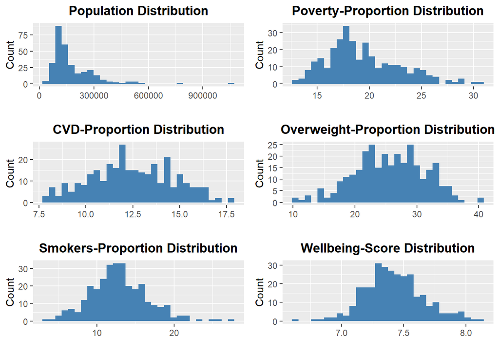

```r
# Create individual plots
plot_population <- ggplot(cvd_data) +
  geom_histogram(aes(x = Population), fill = "steelblue", bins = 30) +
  labs(x = "", y = "Count", title = "Population Distribution") +
  theme(plot.title = element_text(hjust = 0.5, face = "bold"))

plot_poverty <- ggplot(cvd_data) +
  geom_histogram(aes(x = Poverty), fill = "steelblue", bins = 30) +
  labs(x = "", y = "Count", title = "Poverty-Proportion Distribution") +
  theme(plot.title = element_text(hjust = 0.5, face = "bold"))

plot_cvd <- ggplot(cvd_data) +
  geom_histogram(aes(x = CVD), fill = "steelblue", bins = 30) +
  labs(x = "", y = "Count", title = "CVD-Proportion Distribution") +
  theme(plot.title = element_text(hjust = 0.5, face = "bold"))

plot_overweight <- ggplot(cvd_data) +
  geom_histogram(aes(x = overweight), fill = "steelblue", bins = 30) +
  labs(x = "", y = "Count", title = "Overweight-Proportion Distribution") +
  theme(plot.title = element_text(hjust = 0.5, face = "bold"))

plot_smokers <- ggplot(cvd_data) +
  geom_histogram(aes(x = smokers), fill = "steelblue", bins = 30) +
  labs(x = "", y = "Count", title = "Smokers-Proportion Distribution") +
  theme(plot.title = element_text(hjust = 0.5, face = "bold"))

plot_wellbeing <- ggplot(cvd_data) +
  geom_histogram(aes(x = wellbeing), fill = "steelblue", bins = 30) +
  labs(x = "", y = "Count", title = "Wellbeing-Score Distribution") +
  theme(plot.title = element_text(hjust = 0.5, face = "bold"))

# Arrange them in a grid
grid.arrange(
  plot_population, plot_poverty, plot_cvd,
  plot_overweight, plot_smokers, plot_wellbeing,
  nrow = 3, ncol = 2)
```

- All variables directly relevant to the analysis (poverty, CVD, overweight, smokers, wellbeing) appear to be fairly normally distributed and without clear outliers.
- The distribution of population values is visually right-skewed and includes outliers. However, this variable will not be used in further analysis.

## Analysis

### Exploring the Individual Effects of Predictor Variables on the Target Variable

First, we aim to briefly examine the individual relationships between the predictor variables and the target variable with a correlation matrix and visualisations through scatterplots. This will help to identify their potential individual relationships and their strength. Subsequently, we will analyse the joint effects of the predictor variables by performing a multiple linear regression.

**Correlation Matrix (Pearson):**

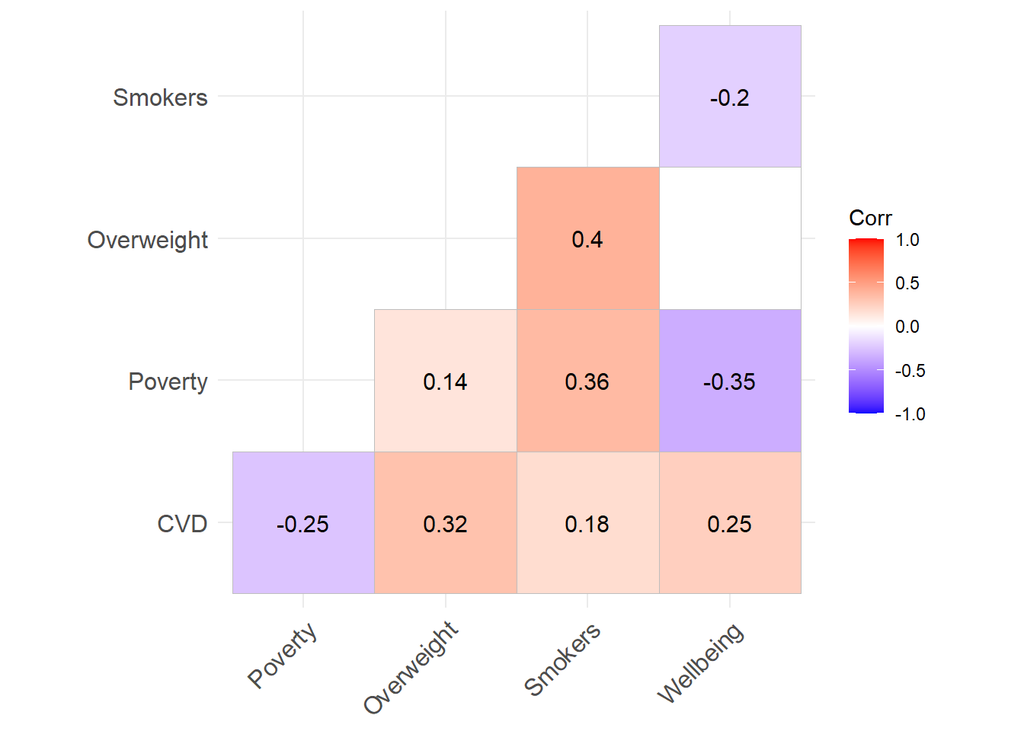

```r
# Calculate the Correlation Matrix
corr_matrix <- rcorr(as.matrix(cvd_data[, c("CVD", "Poverty", "overweight", "smokers", "wellbeing")]), type = "pearson") # As rcorr doesn't work very well with tibbles and data frames we input a matrix

# Correlation Matrix Visualisation

# Extract the correlation values
cor_matrix <- corr_matrix$r

# Rename the variables in the correlation matrix
colnames(cor_matrix) <- c("CVD", "Poverty", "Overweight", "Smokers", "Wellbeing")
rownames(cor_matrix) <- c("CVD", "Poverty", "Overweight", "Smokers", "Wellbeing")

# Extract the p-values
p_matrix <- corr_matrix$P
p_matrix_round <- round(p_matrix, 4)

# Visualise the correlation matrix with ggcorrplot
ggcorrplot(cor_matrix,
           method = "square",
           type = "lower",
           lab = TRUE,
           p.mat = p_matrix,
           insig = "blank")
```

The correlation matrix above shows all pairwise correlations of the variables.

- It can be observed that there is a slight positive correlation between the predictor variables overweight-proportion, smoker-proportion and wellbeing-score with the target variable CVD-proportion, whereas the predictor variable poverty-proportion shows a slight negative correlation with the target variable CVD-proportion.
- The strongest correlation between a variable and the CVD-proportion was found for the overweight-proportion ($r = 0.32$), followed by the poverty-proportion ($r = -0.25$) and wellbeing score ($r = 0.25$). The weakest correlation was found between smokers proportion and CVD-proportion ($r = 0.18$). **Note:** By squaring the $r-value$ we get the proportion of variance explained e.g. $0.32^2 = 0.10$, which means that about 10% of the variance can be explained by overweight.
- All correlations between the predictor variables poverty, overweight, smokers, wellbeing and the target variable CVD are statistically significant as shown below (poverty: $p-value < 0.0001$, overweight: $p-value < 0.0001$, smokers: $p-value = 0.0019$, wellbeing: $p-value < 0.0001$). **Note:** This would align with the coefficient significance of individual linear regressions e.g. CVD ~ overweight.

```r
p_matrix_round
```

```
##               CVD Poverty overweight smokers wellbeing
## CVD            NA  0.0000     0.0000  0.0019    0.0000
## Poverty    0.0000      NA     0.0152  0.0000    0.0000
## overweight 0.0000  0.0152         NA  0.0000    0.4681
## smokers    0.0019  0.0000     0.0000      NA    0.0005
## wellbeing  0.0000  0.0000     0.4681  0.0005        NA
```

**For the interested reader: Correlation Matrix Verification (Spearman):**  
As the distributions (histograms) were not perfectly normally distributed, we additionally determine the correlation matrix below using the Spearman approach to verify the previous results.

```r
( rcorr_spearman <- rcorr(as.matrix(cvd_data[, c("CVD", "Poverty", "overweight", "smokers", "wellbeing")]), type = "spearman") )
```

```
##              CVD Poverty overweight smokers wellbeing
## CVD         1.00   -0.16       0.28    0.19      0.24
## Poverty    -0.16    1.00       0.24    0.40     -0.35
## overweight  0.28    0.24       1.00    0.43     -0.05
## smokers     0.19    0.40       0.43    1.00     -0.17
## wellbeing   0.24   -0.35      -0.05   -0.17      1.00
##
## n= 303
##
##
## P
##            CVD    Poverty overweight smokers wellbeing
## CVD               0.0046  0.0000     0.0011  0.0000
## Poverty    0.0046         0.0000     0.0000  0.0000
## overweight 0.0000 0.0000             0.0000  0.3462
## smokers    0.0011 0.0000  0.0000             0.0024
## wellbeing  0.0000 0.0000  0.3462     0.0024
```

The results are slightly different but they overall support the previous findings. All of the correlations are statistically significant ($p-value < 0.05$). Likewise, overweight, smokers and wellbeing show positive correlations and poverty a negative correlation.

**Scatter Plots:**

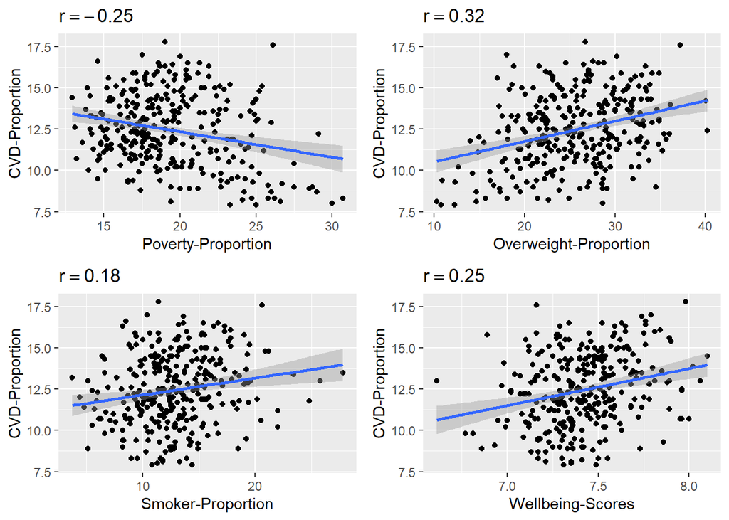

```r
grid.arrange(ggplot(cvd_data, aes(y=CVD, x=Poverty)) + geom_point()
             + labs(x="Poverty-Proportion", y="CVD-Proportion", title=expression(r==-0.25)) +
             geom_smooth(method=lm), ggplot(cvd_data, aes(y=CVD, x=overweight)) + geom_point()
             + labs(x="Overweight-Proportion", y="CVD-Proportion", title=expression(r==0.32)) +
             geom_smooth(method=lm), ggplot(cvd_data, aes(y=CVD, x=smokers)) + geom_point()
             + labs(x="Smoker-Proportion", y="CVD-Proportion", title=expression(r==0.18)) +
             geom_smooth(method=lm), ggplot(cvd_data, aes(y=CVD, x=wellbeing)) + geom_point()
             + labs(x="Wellbeing-Scores", y="CVD-Proportion", title=expression(r==0.25)) +
             geom_smooth(method=lm))
```

The individual scatterplots also reflect the previously described correlations. However, we can also see that these correlations are rather weak.

**Attention:** It is important to understand that correlation does not automatically mean causation (for this you would need to conduct experiments where one variable is changed independently of all the others).

### Exploring the Joint Effects of Predictor Variables on the Target Variable

So far we have only considered individual effects (variables independent of each other). We now change this by estimating a multiple regression model. First we will run the model with the unmodified data (easy to interpret), then we will fit the multiple regression model with the standardised data to better compare the coefficients.

**Multiple Regression Model with unmodified data:**

```r
m.cvd.multiple <- lm(CVD ~ Poverty + overweight + smokers + wellbeing, data = cvd_data)
summary(m.cvd.multiple)
```

```
##
## Call:
## lm(formula = CVD ~ Poverty + overweight + smokers + wellbeing,
##     data = cvd_data)
##
## Residuals:
##     Min      1Q  Median      3Q     Max
## -4.3966 -1.4313 -0.1097  1.3905  4.7779
##
## Coefficients:
##             Estimate Std. Error t value    Pr(>|t|)
## (Intercept) -1.69780    3.93361  -0.432    0.666335
## Poverty     -0.18400    0.03515  -5.234 0.000000313 ***
## overweight   0.10985    0.02123   5.174 0.000000422 ***
## smokers      0.12030    0.03366   3.574    0.000410 ***
## wellbeing    1.80025    0.49096   3.667    0.000291 ***
## ---
## Signif. codes:  0 '***' 0.001 '**' 0.01 '*' 0.05 '.' 0.1 ' ' 1
##
## Residual standard error: 1.894 on 298 degrees of freedom
## Multiple R-squared:  0.2494, Adjusted R-squared:  0.2393
## F-statistic: 24.75 on 4 and 298 DF,  p-value: < 0.00000000000000022
```

```r
cbind(coef(m.cvd.multiple), confint(m.cvd.multiple))
```

```
##                              2.5 %     97.5 %
## (Intercept) -1.6977972 -9.43896508  6.0433707
## Poverty     -0.1839990 -0.25317844 -0.1148195
## overweight   0.1098530  0.06806757  0.1516385
## smokers      0.1203042  0.05405715  0.1865512
## wellbeing    1.8002479  0.83405073  2.7664450
```

The multiple regression shows the following effects upon CVD-proportion (when controlling for the other variables):

- Significant negative effect of poverty-proportion upon CVD-proportion ($t(298)=-5.234$, $p<0.0001$), with every 1% increase in Poverty-proportion predicting an average decrease of 0.1840% in CVD-proportion ($CI = [-0.2532, -0.1148]$).
- Significant positive effect of overweight-proportion upon CVD-proportion ($t(298)=5.174$, $p<0.0001$), with every 1% increase in overweight-proportion predicting an average increase of 0.1099% in CVD-proportion ($CI = [0.0681, 0.1516]$).
- Significant positive effect of smokers-proportion upon CVD-proportion ($t(298)=3.574$, $p=0.0004$), with every 1% increase in smokers-proportion predicting an average increase of 0.1203% in CVD-proportion ($CI = [0.0541, 0.1866]$).
- Significant positive effect of wellbeing-score upon CVD-proportion ($t(298)=3.667$, $p=0.0003$), with every 1 point increase in wellbeing-score predicting an average increase of 1.8003% in CVD-proportion ($CI = [0.8341, 2.7664]$).

Before moving forward, we would like to briefly assess the linear relationship in our multiple linear regression model. To do this, we will create a residual plot to check for randomness and additionally plot the distribution of the residuals, which should be approximately normally distributed.

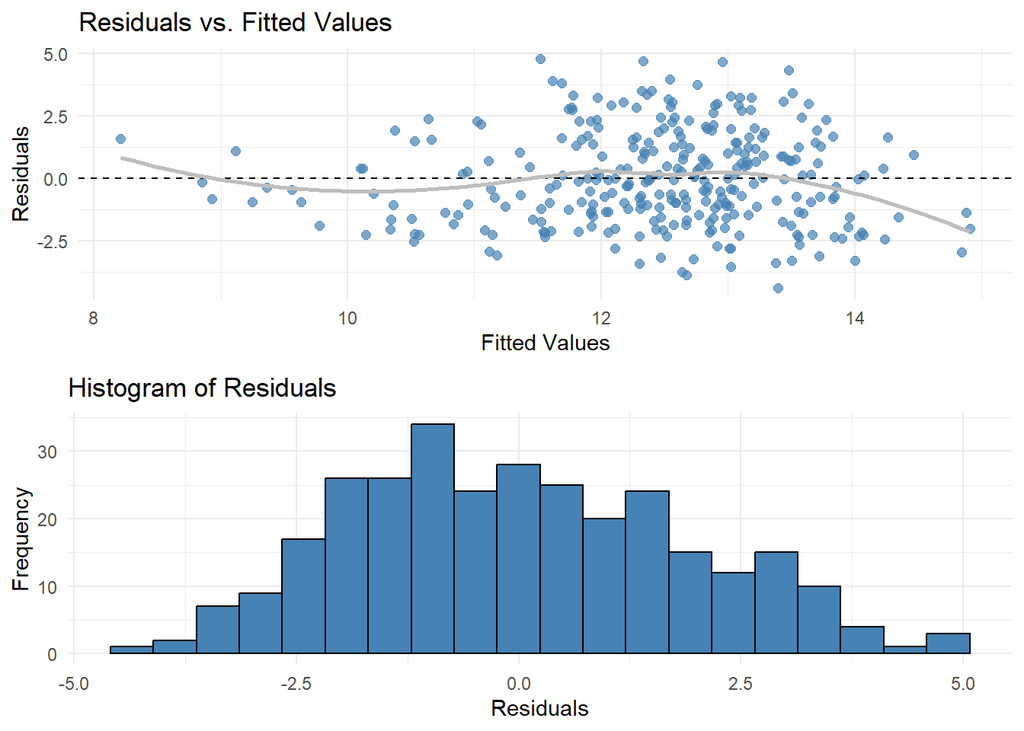

```r
# Extract fitted values and residuals
fitted_values <- fitted(m.cvd.multiple)
residuals_values <- residuals(m.cvd.multiple)

# Create a data frame
residuals_df <- data.frame(Fitted = fitted_values, Residuals = residuals_values)

# Create the ggplot
resid_plot <- ggplot(residuals_df, aes(x = Fitted, y = Residuals)) +
              geom_point(color = "steelblue", size = 2, alpha = 0.7) +
              geom_hline(yintercept = 0, linetype = "dashed", color = "black") +
              geom_smooth(method = "loess", color = "grey", se = FALSE, linetype = "solid", size = 1) +
              labs(title = "Residuals vs. Fitted Values",
                   x = "Fitted Values", y = "Residuals") +
              theme_minimal()

# Create a histogram of residuals
resid_histogram <- ggplot(data.frame(residuals_values)) +
  geom_histogram(aes(x = residuals_values), fill = "steelblue", bins = 20, colour = "black") +
  labs(x = "Residuals", y = "Frequency", title = "Histogram of Residuals") +
  theme_minimal()

grid.arrange(resid_plot, resid_histogram, nrow = 2)
```

We observe no obvious patterns in the residual plot, and the residuals appear to be fairly normally distributed, which suggests a linear relationship.

**Note:** It is important to note that the variables in this analysis are measured on different scales. For example, wellbeing is measured as a score ranging from 1 to 10, whereas the other variables are proportions expressed on a 0-100 scale. Using the raw values allows for straightforward interpretations, such as: an increase of 1% in the smoker-proportion leads to an increase of 0.1203% in the CVD-proportion. However, to compare the coefficients across variables more effectively, we will use the standardised data in the next step.

**Multiple Regression Model with standardised data:**

```r
# Creating a dataset with standardised values
cvd_data_standardised <- cvd_data %>%
  mutate(
    CVD = scale(CVD),
    Poverty = scale(Poverty),
    overweight = scale(overweight),
    smokers = scale(smokers),
    wellbeing = scale(wellbeing))

# Run the multiple regression model with standardised values
m.cvd.multiple.stand <- lm(CVD ~ Poverty + overweight + smokers + wellbeing, data = cvd_data_standardised)
summary(m.cvd.multiple.stand)
```

```
##
## Call:
## lm(formula = CVD ~ Poverty + overweight + smokers + wellbeing,
##     data = cvd_data_standardised)
##
## Residuals:
##      Min       1Q   Median       3Q      Max
## -2.02503 -0.65926 -0.05053  0.64045  2.20066
##
## Coefficients:
##                           Estimate             Std. Error t value    Pr(>|t|)
## (Intercept)  0.0000000000000001512  0.0501058198586275400   0.000    1.000000
## Poverty     -0.2952414433016536388  0.0564058011315120428  -5.234 0.000000313 ***
## overweight   0.2840357374268674406  0.0548997846511883464   5.174 0.000000422 ***
## smokers      0.2091117723743945722  0.0585125021952828811   3.574    0.000410 ***
## wellbeing    0.1969639167162149929  0.0537161178783139431   3.667    0.000291 ***
## ---
## Signif. codes:  0 '***' 0.001 '**' 0.01 '*' 0.05 '.' 0.1 ' ' 1
##
## Residual standard error: 0.8722 on 298 degrees of freedom
## Multiple R-squared:  0.2494, Adjusted R-squared:  0.2393
## F-statistic: 24.75 on 4 and 298 DF,  p-value: < 0.00000000000000022
```

```r
cbind(coef(m.cvd.multiple.stand), confint(m.cvd.multiple.stand))
```

```
##                                             2.5 %      97.5 %
## (Intercept)  0.0000000000000001512331 -0.09860607  0.09860607
## Poverty     -0.2952414433016536388088 -0.40624561 -0.18423728
## overweight   0.2840357374268674406359  0.17599535  0.39207613
## smokers      0.2091117723743945722159  0.09396171  0.32426183
## wellbeing    0.1969639167162149928636  0.09125293  0.30267490
```

The multiple regression with standardised data gives us the following information:

- All predictors are still highly significant (same p-values as multiple regression with unmodified data).
- In comparison to the correlation analysis (which examines individual relationships between the predictor and target variables), there is a slight shift in effects: Poverty now appears to have the strongest effect (-0.2952), while overweight remains very important (0.2840). Smokers (0.2091) and wellbeing (0.1969) follow, with slightly less weight.
- The differences in results compared to the individual effects (gathered from the correlation analysis) can be explained by the dependencies between the variables. For example, wellbeing may depend on poverty, as shown by their negative correlation in the Pearson Correlation Matrix ($r-value = -0.35$). The higher the level of poverty, the lower the wellbeing score.

Due to these **possible dependencies** between the predictor variables, such as the negative correlation between poverty and wellbeing, it is necessary to check for multicollinearity. To do this, we calculate the Variance Inflation Factor scores (VIFs) to identify strong collinearity in our regression model, which could make the results unreliable.

```r
# Check for multicollinearity
vif(m.cvd.multiple)
```

```
##    Poverty overweight    smokers  wellbeing
##   1.263094   1.196546   1.359206   1.145506
```

The output shows that there is no severe data-based multicollinearity (All scores are clearly below the cut-off point of 5). Therefore, we do not need to undertake any corrections (e.g. exclusion of a predictor variables).

### Visualising the Impact of Poverty on Cardiovascular Disease (CVD)

As requested by the task, we will provide visualisations below which illustrate the impact of poverty on cardiovascular disease (CVD).

As it is not entirely clear from the task whether the pure relationship between poverty and CVD should be plotted or whether the adjusted effect of poverty on CVD (via a prediction output of the multiple regression model) should be visualised, both methods will be presented below.

**Raw relationship between Poverty and CVD:**

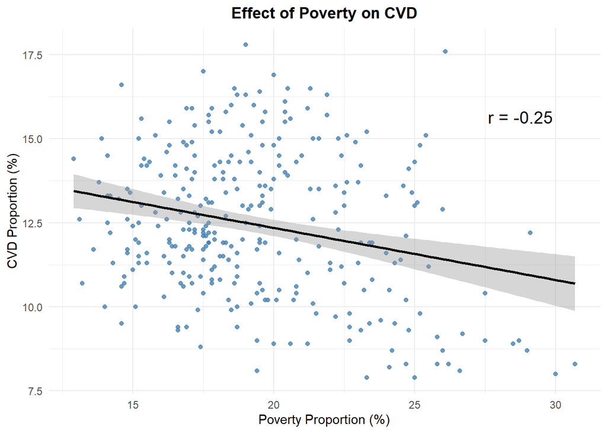

```r
ggplot(cvd_data, aes(x = Poverty, y = CVD)) +
  geom_point(size = 1.5, alpha = 0.8, colour = "steelblue") +
  geom_smooth(method = "lm", colour = "black") +
  labs(title = "Effect of Poverty on CVD",
       x = "Poverty Proportion (%)",
       y = "CVD Proportion (%)") +
  theme_minimal() +
  theme(plot.title = element_text(hjust = 0.5, face = "bold")) +
  annotate("text", x = 28.75, y = 15.65,
           label = "r = -0.25", size = 5, colour = "black")
```

The plot shows the relationship between poverty-proportion (%) and CVD-proportion (%). A weak negative correlation is indicated by the black line (Pearson-Correlation-Coefficent: $r=-0.25$), where higher poverty levels are associated with slightly lower CVD-proportions. A potential reason for this (which would require further research) could be differences in access to healthcare and check-ups.

**Adjusted effect of poverty on CVD (via a prediction output of the multiple regression model):**

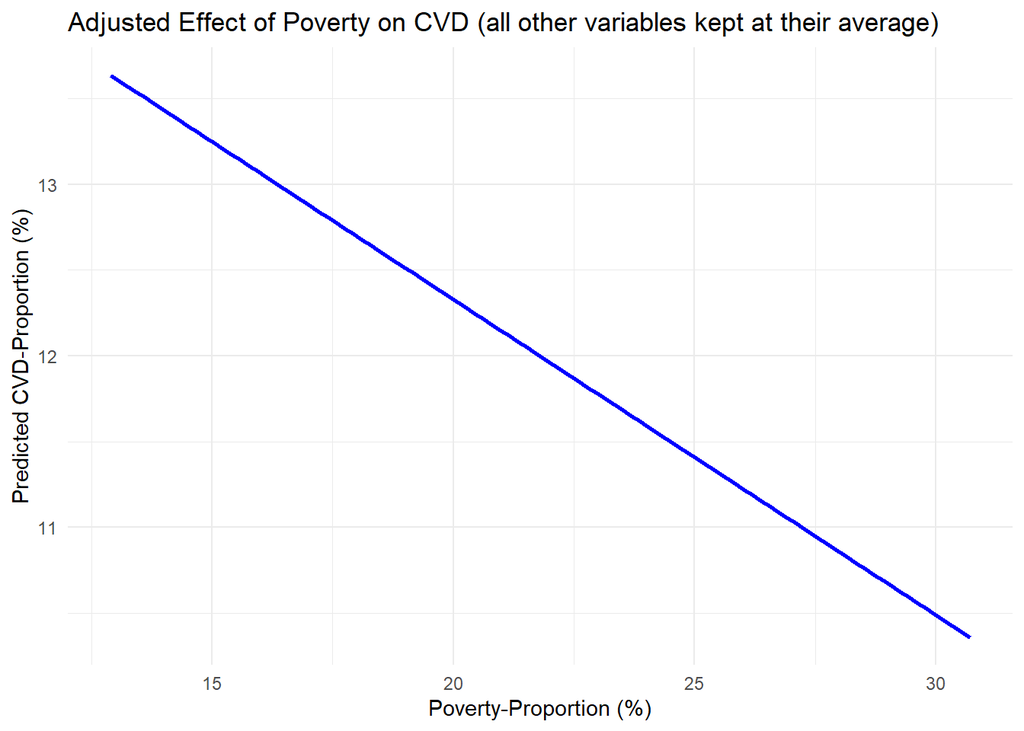

```r
# Create a new data frame for the prediction
cvd_prediction_data <- data.frame(
  Poverty = seq(min(cvd_data$Poverty), max(cvd_data$Poverty), length.out = 100),
  overweight = mean(cvd_data$overweight, na.rm = TRUE),
  smokers = mean(cvd_data$smokers, na.rm = TRUE),
  wellbeing = mean(cvd_data$wellbeing, na.rm = TRUE))
  # Creates a data frame with 100 rows. The average values for overweight, smokers, and wellbeing are calculated and kept constant. For poverty, 100 equally distributed values are generated, ranging from the minimum to the maximum value in the current (real) data frame.

# Predict values based on the model
cvd_prediction_data$predicted_CVD <- predict(m.cvd.multiple, newdata = cvd_prediction_data)

# Plot the adjusted effect of Poverty on CVD
ggplot(cvd_prediction_data, aes(x = Poverty, y = predicted_CVD)) +
  geom_line(color = "blue", size = 1) +
  labs(title = "Adjusted Effect of Poverty on CVD (all other variables kept at their average)",
       x = "Poverty-Proportion (%)",
       y = "Predicted CVD-Proportion (%)") +
  theme_minimal()
```

The plot shows the effect of poverty while keeping all other variables (overweight, smokers, wellbeing) constant at their average value (calculated from the actual dataset). Once again, we observe the negative trend in the relationship.

## Conclusion

We examined the predictor variables overweight, smokers, wellbeing and poverty, both individually (using a correlation matrix and scatter plots) and while accounting for interdependencies (via multiple regression). Across all analyses, all coefficients were highly significant and contributed to the model’s explanatory power. Overweight consistently stood out as a very influential factor in both the correlation analysis and multiple regression. Poverty also emerged as a key factor, showing a particularly strong influence in the multiple regression model. The other two variables wellbeing and smokers, were both significant as well but had a comparatively slightly weaker effect (in the multiple regression). Furthermore, we assessed multicollinearity, which did not substantially impact the analysis, as only weak collinearity was detected.

**Addition Information:**

**Further research:** It would be particularly interesting to investigate why poverty seems to have a strong negative effect on the CVD proportion. Possible explanations (not proven) could include a lack of access to healthcare services for people from poorer backgrounds, fewer check-ups compared to others or other factors that might be found.

**Interaction effects:** Although we have not tested interaction terms in this analysis, it is possible to formulate new hypotheses to explore interactions (e.g. is the effect of being overweight on CVD the same across different levels of smoker proportions?). Testing interaction terms randomly and only keeping the ones with significant results can lead to p-hacking, which may cause overfitting and unreliable conclusions. Since testing interactions is not required for this task, we will not include them in this analysis.

# Question 2 – Customer Satisfaction

The code below performs the following analyses as required:

- Identification of factors influencing customer satisfaction: Determine which of the given factors (average staff job satisfaction score, average delivery time of large and custom items, whether the store was carrying a new range of products and the company’s categorisation of store type by local socio-economic status (low, medium, and high)) has the strongest influence on customer satisfaction.
- Evaluation of the effect of delivery times on customer satisfaction: Assess whether the effect of delivery times on customer satisfaction differs across high, medium, and low socio-economic status (SES) stores.

## Data dictionary

The data used for the following analyses originates from a furniture retail company. Each row in the dataset represents one store.

The dataset variables are described in the following table:

| Variable | Description |
| --- | --- |
| SES_category | Socio-economic status (SES) of the store type (Low, Medium or High) |
| customer.satisfaction | Average customer satisfaction score for the store |
| staff.satisfaction | Average job satisfaction score of the store’s staff |
| delivery.time | Average delivery time (in days) for large and custom items delivered from the store |
| new_range | Indicates whether the store is carrying a new range of products (TRUE = Yes, FALSE = No) |

## Data import and overview

```r
cust_satisfaction <- read_csv("cust_satisfaction.csv")
head(cust_satisfaction)
```

```
## # A tibble: 6 × 5
##   SES_category customer.satisfaction staff.satisfaction delivery.time new_range
##   <chr>                        <dbl>              <dbl>         <dbl> <lgl>
## 1 Medium                        7.27               6.88          66.7 FALSE
## 2 Medium                        7.93               7.44          68.2 FALSE
## 3 Medium                        7.12               7.15          70.7 FALSE
## 4 High                          6.35               6.47          61.4 TRUE
## 5 High                          6.78               7.06          57.7 TRUE
## 6 Medium                        8.07               7.03          38.0 TRUE
```

## Integrity & Quality check

**Structure check:**

```r
str(cust_satisfaction)
```

```
## spc_tbl_ [300 × 5] (S3: spec_tbl_df/tbl_df/tbl/data.frame)
##  $ SES_category         : chr [1:300] "Medium" "Medium" "Medium" "High" ...
##  $ customer.satisfaction: num [1:300] 7.27 7.93 7.12 6.35 6.78 ...
##  $ staff.satisfaction   : num [1:300] 6.88 7.44 7.15 6.47 7.06 ...
##  $ delivery.time        : num [1:300] 66.7 68.2 70.7 61.4 57.7 ...
##  $ new_range            : logi [1:300] FALSE FALSE FALSE TRUE TRUE TRUE ...
##  - attr(*, "spec")=
##   .. cols(
##   ..   SES_category = col_character(),
##   ..   customer.satisfaction = col_double(),
##   ..   staff.satisfaction = col_double(),
##   ..   delivery.time = col_double(),
##   ..   new_range = col_logical()
##   .. )
##  - attr(*, "problems")=<externalptr>
```

- The data types for customer.satisfaction, staff.satisfaction and delivery.time are ok
- The data types for SES_category and new_range will be transformed into factors (in the following code block)

**Factor transformation:**

```r
# Unique value check (SES_category: Only Low, Medium, High? / new_range: Only FALSE, TRUE?)
unique(cust_satisfaction$SES_category)
```

```
## [1] "Medium" "High"   "Low"
```

```r
unique(cust_satisfaction$new_range)
```

```
## [1] FALSE  TRUE
```

```r
# Transforming SES_category and new_range into factors
cust_satisfaction$SES_category <- factor(cust_satisfaction$SES_category,
                                         levels = c("Low", "Medium", "High"))

cust_satisfaction$new_range <- factor(cust_satisfaction$new_range,
                                      levels = c(FALSE, TRUE),
                                      labels = c("No", "Yes"))
```

**Check whether the transformations were successful:**

```r
str(cust_satisfaction)
```

```
## spc_tbl_ [300 × 5] (S3: spec_tbl_df/tbl_df/tbl/data.frame)
##  $ SES_category         : Factor w/ 3 levels "Low","Medium",..: 2 2 2 3 3 2 2 2 2 3 ...
##  $ customer.satisfaction: num [1:300] 7.27 7.93 7.12 6.35 6.78 ...
##  $ staff.satisfaction   : num [1:300] 6.88 7.44 7.15 6.47 7.06 ...
##  $ delivery.time        : num [1:300] 66.7 68.2 70.7 61.4 57.7 ...
##  $ new_range            : Factor w/ 2 levels "No","Yes": 1 1 1 2 2 2 2 1 1 2 ...
##  - attr(*, "spec")=
##   .. cols(
##   ..   SES_category = col_character(),
##   ..   customer.satisfaction = col_double(),
##   ..   staff.satisfaction = col_double(),
##   ..   delivery.time = col_double(),
##   ..   new_range = col_logical()
##   .. )
##  - attr(*, "problems")=<externalptr>
```

The factor transformations were successful.

**Duplicate check:**

```r
sum(duplicated(cust_satisfaction))
```

```
## [1] 0
```

We do not have any duplicates in the data.

**Check the data set for missing values:**

```r
# Count the missing values per variable
sapply(cust_satisfaction, function(x) sum(is.na(x)))
```

```
##          SES_category customer.satisfaction    staff.satisfaction         delivery.time
##                     0                     0                     0                     0
##             new_range
##                     0
```

We do not have any missing values in the data.

**Some visuals to check the distribution of the data:**

Histograms (of numerical variables):

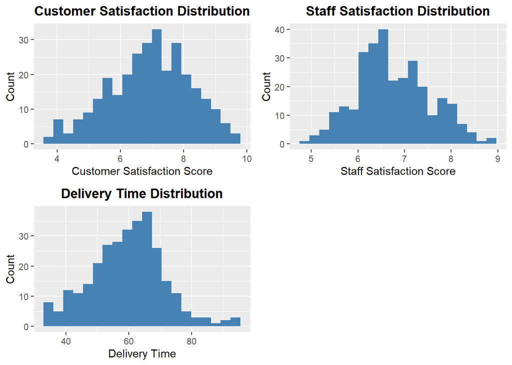

```r
# Create individual plots
plot_customer_satisfaction <- ggplot(cust_satisfaction) +
  geom_histogram(aes(x = customer.satisfaction), fill = "steelblue", bins = 20) +
  labs(x = "Customer Satisfaction Score", y = "Count", title = "Customer Satisfaction Distribution") +
  theme(plot.title = element_text(hjust = 0.5, face = "bold"))

plot_staff_satisfaction <- ggplot(cust_satisfaction) +
  geom_histogram(aes(x = staff.satisfaction), fill = "steelblue", bins = 20) +
  labs(x = "Staff Satisfaction Score", y = "Count", title = "Staff Satisfaction Distribution") +
  theme(plot.title = element_text(hjust = 0.5, face = "bold"))

plot_delivery_time <- ggplot(cust_satisfaction) +
  geom_histogram(aes(x = delivery.time), fill = "steelblue", bins = 20) +
  labs(x = "Delivery Time", y = "Count", title = "Delivery Time Distribution") +
  theme(plot.title = element_text(hjust = 0.5, face = "bold"))

# Arrange them in a grid
grid.arrange(plot_customer_satisfaction, plot_staff_satisfaction, plot_delivery_time, nrow = 2, ncol = 2)
```

All distributions look fine and fairly normally distributed, with no visual outliers.

Barplots (for factor variables):

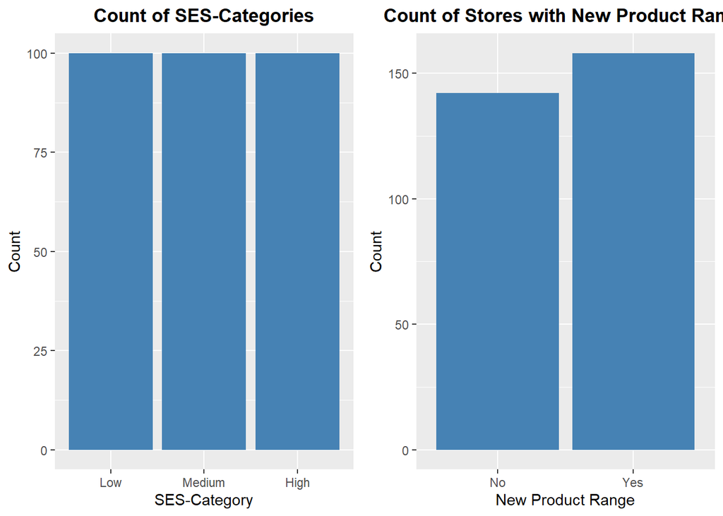

```r
# Create individual plots
plot_SES_category <- ggplot(cust_satisfaction) +
  geom_bar(aes(x = SES_category), fill = "steelblue") +
  labs(x = "SES-Category", y = "Count", title = "Count of SES-Categories") +
  theme(plot.title = element_text(hjust = 0.5, face = "bold"))

plot_new_range <- ggplot(cust_satisfaction) +
  geom_bar(aes(x = new_range), fill = "steelblue") +
  labs(x = "New Product Range", y = "Count", title = "Count of Stores with New Product Range") +
  theme(plot.title = element_text(hjust = 0.5, face = "bold"))

# Arrange them in a grid
grid.arrange(plot_SES_category, plot_new_range, nrow = 1, ncol = 2)
```

- We recognise that the store types (socio-economic status) are evenly represented in the data (100 stores per category).
- Likewise, the stores which are carrying a new range of products versus those which are NOT carrying a new range of products are represented approximately equally often.
- Both categorical variables are therefore balanced.

## Analysis

### Exploring the Individual Effects of Predictor Variables on the Target Variable

First, we aim to briefly examine the individual relationships between the predictor variables and the target variable with a correlation matrix and visualisations through scatterplots. This will help to identify their potential individual relationships and their strength. Subsequently, we will analyse the joint effects of the predictor variables by performing a multiple linear regression.

#### Continuous variables

**Correlation Matrix (Pearson) for continous variables:**

```r
# Calculate the Correlation Matrix
rcorr(as.matrix(cust_satisfaction[, c("customer.satisfaction", "staff.satisfaction", "delivery.time")]),
      type = "pearson") # As rcorr doesn't work very well with tibbles and data frames we input a matrix
```

```
##                       customer.satisfaction staff.satisfaction delivery.time
## customer.satisfaction                  1.00               0.45         -0.26
## staff.satisfaction                     0.45               1.00         -0.07
## delivery.time                         -0.26              -0.07          1.00
##
## n= 300
##
##
## P
##                       customer.satisfaction staff.satisfaction delivery.time
## customer.satisfaction                       0.0000             0.0000
## staff.satisfaction    0.0000                                   0.2602
## delivery.time         0.0000                0.2602
```

**First Table (R-Values):**

- The correlation matrix above shows all pairwise correlations of the continuous variables.
- It can be seen that there is a noticeable positive correlation between customer satisfaction and staff satisfaction ($r = 0.45$) and also a slight negative correlation between customer satisfaction and delivery time ($r = -0.26$). **Note:** By squaring the $r-value$ we get the proportion of variance explained e.g. $0.45^2 = 0.20$, which means that about 20% of the variance can be explained by the staff satisfaction.

**Second Table (P-Values):**

- All correlations between the two continuous variables staff satisfaction, delivery time and the dependent variable customer satisfaction are statistically significant (staff.satisfaction: $p-value < 0.0001$, delivery.time: $p-value < 0.0001$). **Note:** This would align with the coefficient significance of individual linear regressions e.g. customer.satisfaction ~ staff.satisfaction.

**For the interested reader: Correlation Matrix Verification (Spearman):**  
As the distributions (histograms) were not perfectly normally distributed, we additionally determine the correlation matrix below using the Spearman approach to verify the previous results.

```r
( rcorr_spearman <- rcorr(as.matrix(cust_satisfaction[, c("customer.satisfaction", "staff.satisfaction", "delivery.time")]), type = "spearman") )
```

```
##                       customer.satisfaction staff.satisfaction delivery.time
## customer.satisfaction                  1.00               0.44         -0.26
## staff.satisfaction                     0.44               1.00         -0.04
## delivery.time                         -0.26              -0.04          1.00
##
## n= 300
##
##
## P
##                       customer.satisfaction staff.satisfaction delivery.time
## customer.satisfaction                       0.0000             0.0000
## staff.satisfaction    0.0000                                   0.4448
## delivery.time         0.0000                0.4448
```

The results show a practically unchanged picture.

**Scatter Plots:**

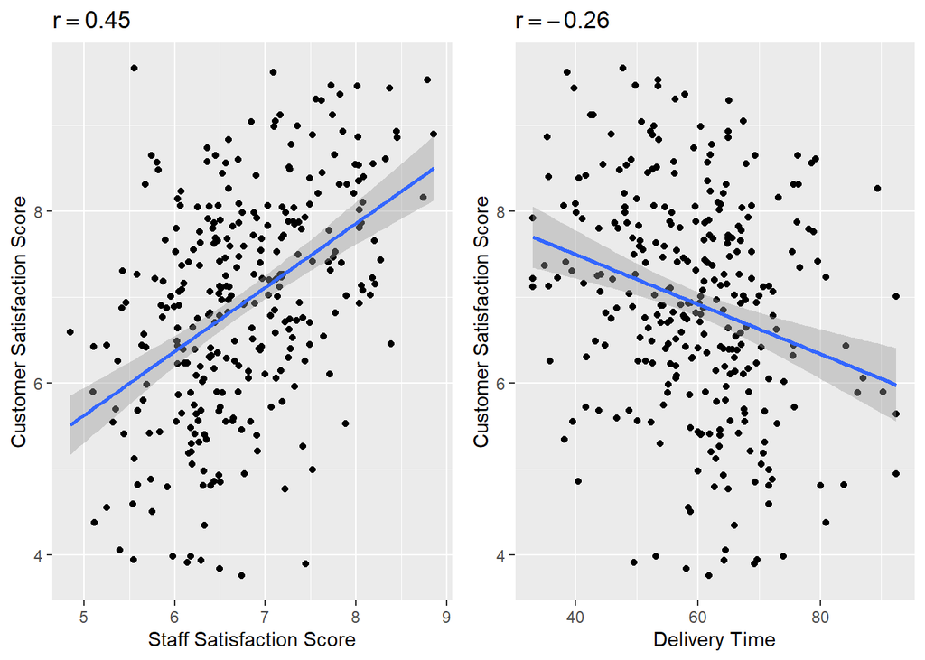

```r
grid.arrange(ggplot(cust_satisfaction, aes(y=customer.satisfaction, x=staff.satisfaction)) + geom_point()
             + labs(x="Staff Satisfaction Score", y="Customer Satisfaction Score", title=expression(r==0.45)) +
               geom_smooth(method=lm),
             ggplot(cust_satisfaction, aes(y=customer.satisfaction, x=delivery.time)) + geom_point()
             + labs(x="Delivery Time", y="Customer Satisfaction Score", title=expression(r==-0.26)) +
               geom_smooth(method=lm),
             ncol = 2)
```

The individual scatterplots also reflect the previously described correlations. We can see the noticeable positive correlation between customer satisfaction and staff satisfaction, as well as the slight negative correlation between customer satisfaction and delivery time.

**Attention:** It is important to understand that correlation does not automatically mean causation (for this you would need to conduct experiments where one variable is changed independently of all the others).

#### Factor Variables

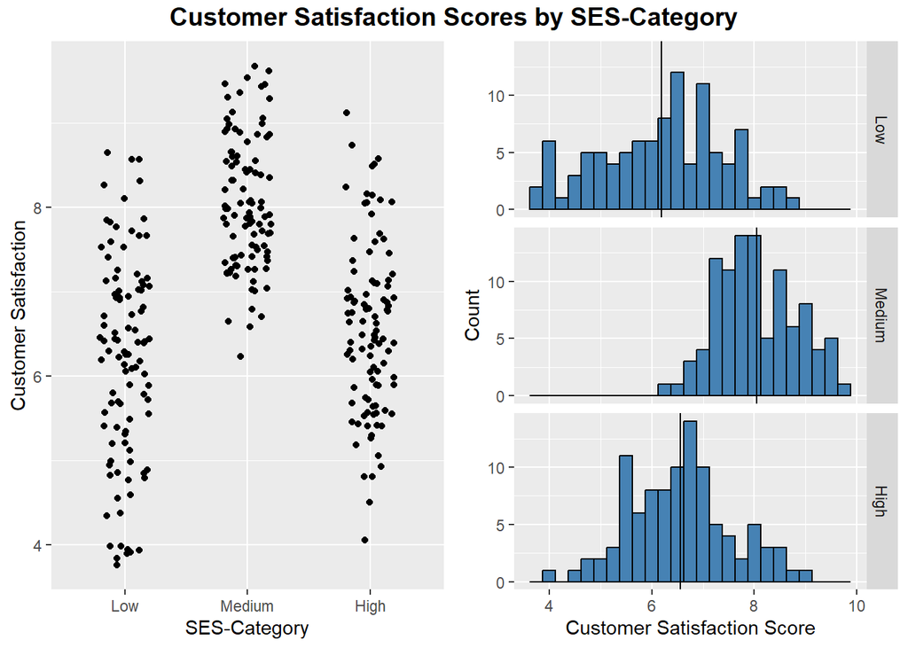

```r
# Visualisation factor variable: SES_category

# Calculation of mean customer satisfaction grouped by SES_category
mean_score_by_SES_category <- cust_satisfaction %>%
  group_by(SES_category) %>%
  summarise(frequency=n(),
            mean=mean(customer.satisfaction))

# Scatter plot - Customer satisfaction by SES-category
cs_ses_1 <- ggplot(cust_satisfaction) + geom_jitter(aes(x = SES_category, y = customer.satisfaction),
                   width = 0.2) + labs(x = "SES-Category", y = "Customer Satisfaction")

# Histograms - Distribution of customer satisfaction scores by SES-category
cs_ses_2 <- ggplot(cust_satisfaction) +
  geom_histogram(aes(x = customer.satisfaction), fill = "steelblue", binwidth = 0.25, color = "black") +
  geom_vline(data = mean_score_by_SES_category, mapping = aes(xintercept = mean), col = "black") +
  facet_grid(SES_category ~ .) +
  labs(x = "Customer Satisfaction Score", y = "Count")

# Output in one grid (2 columns)
grid.arrange(
  arrangeGrob(cs_ses_1, cs_ses_2, ncol = 2),
  top = textGrob("Customer Satisfaction Scores by SES-Category",
                 gp = gpar(fontsize = 14, fontface = "bold")))
```

- The customer satisfaction scores for medium SES-category stores appear to be generally higher than for the low and high SES-category.
- The low versus high SES-category does not show any major differences, perhaps the values are slightly higher for shops in the high SES-category.

**Note:** We could perform multiple t-tests at this point to compare the means between the different SES-category store sizes (low-medium, medium-high, low-high). However, since we will later analyse the impact of the categorical variables on the target variable using ANOVA and marginal means, we will not conduct the t-tests here.

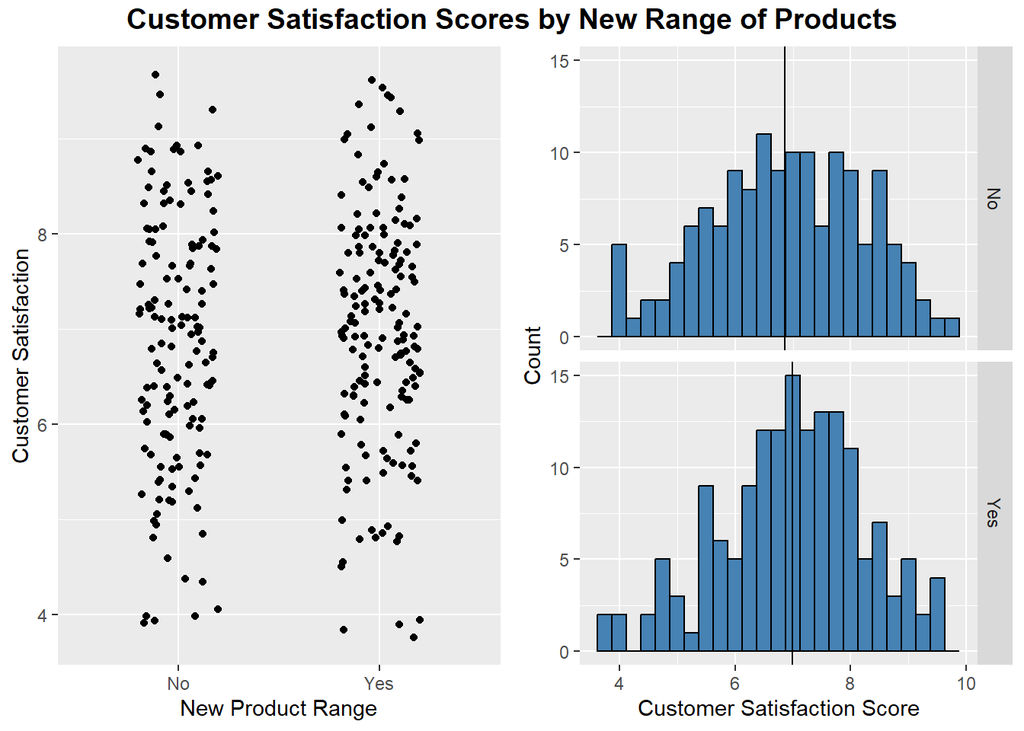

```r
# Visualisation factor variable: new_range

# Calculation of mean customer satisfaction grouped by new_range
mean_score_by_new_range <- cust_satisfaction %>%
  group_by(new_range) %>%
  summarise(frequency=n(),
            mean=mean(customer.satisfaction))

# Scatter plot - Customer satisfaction by new_range
cs_nr_1 <- ggplot(cust_satisfaction) + geom_jitter(aes(x = new_range, y = customer.satisfaction), width = 0.2) +
                                     labs(x = "New Product Range", y = "Customer Satisfaction")

# Histograms - Distribution of customer satisfaction scores by new_range
cs_nr_2 <- ggplot(cust_satisfaction) +
  geom_histogram(aes(x = customer.satisfaction), fill = "steelblue", binwidth = 0.25, color = "black") +
  geom_vline(data = mean_score_by_new_range, mapping = aes(xintercept = mean), col = "black") +
  facet_grid(new_range ~ .) +
  labs(x = "Customer Satisfaction Score", y = "Count")

# Output in one grid (2 columns)
grid.arrange(
  arrangeGrob(cs_nr_1, cs_nr_2, ncol = 2),
  top = textGrob("Customer Satisfaction Scores by New Range of Products",
                 gp = gpar(fontsize = 14, fontface = "bold")))
```

- Between stores with a new range of products and those without, no significant difference in customer satisfaction scores is evident.

**Note:** We could again prove this with a t-tests. However, since we will later analyse the impact of the categorical variables on the target variable using ANOVA and marginal means, we will not conduct the t-test here.

**Impact of categorical variables on customer satisfaction: ANOVA and marginal means analysis:**

For the categorical variables, we use the anova()-function to check if they significantly influence customer satisfaction scores. We also calculate the estimated marginal means, compare the differences between factor levels, and create a visualisation to show how the levels differ and whether these differences affect customer satisfaction.

```r
# SES-category:
m.cs.by.SES <- lm(customer.satisfaction~SES_category, data=cust_satisfaction)
 anova(m.cs.by.SES)
```

```
## Analysis of Variance Table
##
## Response: customer.satisfaction
##               Df Sum Sq Mean Sq F value                Pr(>F)
## SES_category   2 193.16  96.579  93.835 < 0.00000000000000022 ***
## Residuals    297 305.69   1.029
## ---
## Signif. codes:  0 '***' 0.001 '**' 0.01 '*' 0.05 '.' 0.1 ' ' 1
```

The function `anova()` tests whether the variable `SES_category` has a significant effect on the customer satisfaction score. Here we conclude: “The customer satisfaction scores differs significantly across different SES-categories, $F(2,297)=93.835$, $p < 0.0001$”.

**Pairwise comparison:**

```r
# Emmeans, pairwise differences and confidence interval calculations
(  m.cs.by.SES.emm <- emmeans(m.cs.by.SES, ~SES_category)  )
```

```
##  SES_category emmean    SE  df lower.CL upper.CL
##  Low            6.19 0.101 297     5.99     6.39
##  Medium         8.04 0.101 297     7.85     8.24
##  High           6.55 0.101 297     6.35     6.75
##
## Confidence level used: 0.95
```

```r
(  m.cs.by.SES.pairs <- pairs(m.cs.by.SES.emm)  )
```

```
##  contrast      estimate    SE  df t.ratio p.value
##  Low - Medium    -1.855 0.143 297 -12.927  <.0001
##  Low - High      -0.364 0.143 297  -2.536  0.0314
##  Medium - High    1.491 0.143 297  10.391  <.0001
##
## P value adjustment: tukey method for comparing a family of 3 estimates
```

```r
(  m.cs.by.SES.pairs <- confint(pairs(m.cs.by.SES.emm))  )
```

```
##  contrast      estimate    SE  df lower.CL upper.CL
##  Low - Medium    -1.855 0.143 297   -2.193  -1.5167
##  Low - High      -0.364 0.143 297   -0.702  -0.0259
##  Medium - High    1.491 0.143 297    1.153   1.8288
##
## Confidence level used: 0.95
## Conf-level adjustment: tukey method for comparing a family of 3 estimates
```

In the outputs above, we can see that all pairings are significantly different (all $p$-values < 0.05 and all 95% confidence intervals do not include 0).

**Visualisation of the findings above:**

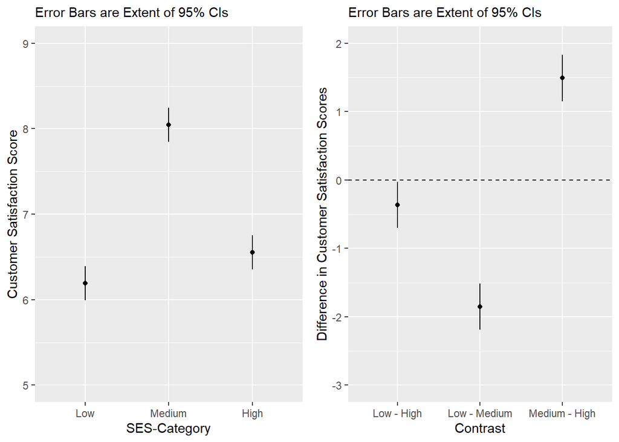

```r
# Plot Emmeans and 95%-CI
p.cs <- ggplot(summary(m.cs.by.SES.emm), aes(x=SES_category, y=emmean, ymin=lower.CL, ymax=upper.CL)) +
       geom_point() + geom_linerange() + labs(x="SES-Category", y="Customer Satisfaction Score",
                                              subtitle="Error Bars are Extent of 95% CIs") + ylim(5,9)

# Plot Contrasts and 95%-CI
p.contrasts <- ggplot(m.cs.by.SES.pairs, aes(x=contrast, y=estimate, ymin=lower.CL, ymax=upper.CL)) +
                      geom_point() + geom_linerange() + geom_hline(yintercept=0, lty=2) + labs(x="Contrast",
                      y="Difference in Customer Satisfaction Scores", subtitle="Error Bars are Extent of 95% CIs") +
                      ylim(-3,2)

# Arrange in one grid (2 columns)
grid.arrange(p.cs, p.contrasts, ncol=2)
```

- The left panel of the above Figure shows the mean customer satisfaction scores for the different SES-categories. The medium SES-category stores have the highest mean customer satisfaction score, followed by high SES-category stores and low SES-category stores.
- The right panel shows the estimates of the difference in customer satisfaction scores for each pair of SES-category stores. It can be seen that the differences for all pairs are statistically significant, but the difference between low and high SES-category stores is fairly small.

The same evaluations can now also be conducted for new range products.

```r
# New range products:
m.cs.by.nrp <- lm(customer.satisfaction~new_range, data=cust_satisfaction)
 anova(m.cs.by.nrp)
```

```
## Analysis of Variance Table
##
## Response: customer.satisfaction
##            Df Sum Sq Mean Sq F value Pr(>F)
## new_range   1   1.26  1.2593  0.7542 0.3858
## Residuals 298 497.58  1.6697
```

The function `anova()` tests whether the variable `new_range` has a significant effect on the customer satisfaction score. We can say “The customer satisfaction scores do **not** differs significantly across stores with or without new range products, $F(1,298)=0.7542$, $p = 0.3858$”.

**Pairwise comparison:**

```r
# Emmeans, pairwise differences and confidence interval calculations
(  m.cs.by.nrp.emm <- emmeans(m.cs.by.nrp, ~new_range)  )
```

```
##  new_range emmean    SE  df lower.CL upper.CL
##  No          6.86 0.108 298     6.65     7.07
##  Yes         6.99 0.103 298     6.79     7.19
##
## Confidence level used: 0.95
```

```r
(  m.cs.by.nrp.pairs <- pairs(m.cs.by.nrp.emm)  )
```

```
##  contrast estimate    SE  df t.ratio p.value
##  No - Yes    -0.13 0.149 298  -0.868  0.3858
```

```r
(  m.cs.by.nrp.pairs <- confint(pairs(m.cs.by.nrp.emm))  )
```

```
##  contrast estimate    SE  df lower.CL upper.CL
##  No - Yes    -0.13 0.149 298   -0.424    0.164
##
## Confidence level used: 0.95
```

In the outputs above, we can see again that there is no significant difference between category No and Yes ($p-value = 0.3858$ and the 95% confidence interval includes 0).

**Visualisation of the findings above:**

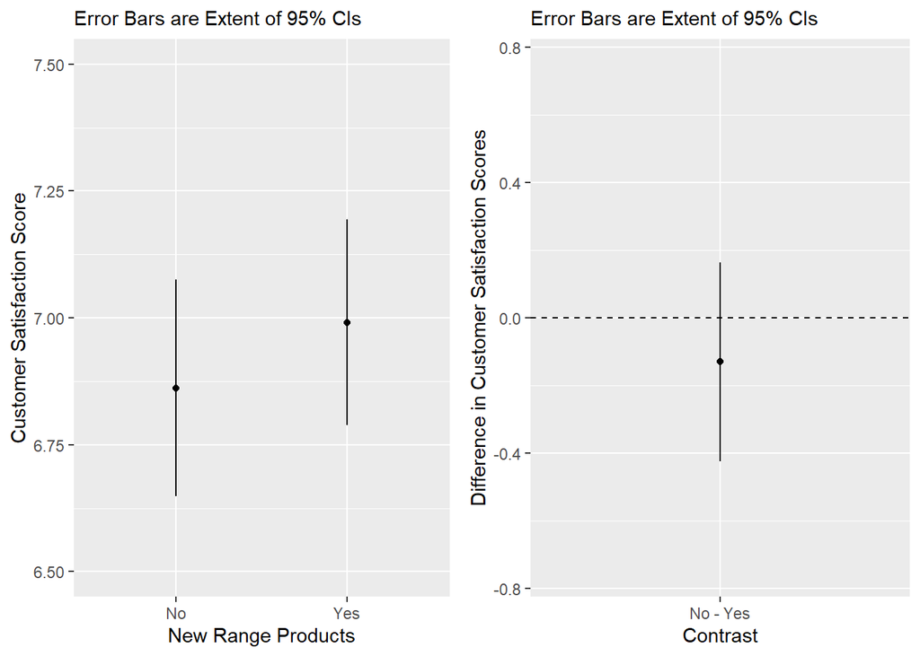

```r
# Plot Emmeans and 95%-CI
p.cs <- ggplot(summary(m.cs.by.nrp.emm), aes(x=new_range, y=emmean, ymin=lower.CL, ymax=upper.CL)) +
        geom_point() + geom_linerange() + labs(x="New Range Products", y="Customer Satisfaction Score",
                                               subtitle="Error Bars are Extent of 95% CIs") + ylim(6.5,7.5)

# Plot Contrasts and 95%-CI
p.contrasts <- ggplot(m.cs.by.nrp.pairs, aes(x=contrast, y=estimate, ymin=lower.CL, ymax=upper.CL)) +
                      geom_point() + geom_linerange() + geom_hline(yintercept=0, lty=2) + labs(x="Contrast",
                      y="Difference in Customer Satisfaction Scores", subtitle="Error Bars are Extent of 95% CIs") +
                      ylim(-0.75,0.75)

# Arrange in one grid (2 columns)
grid.arrange(p.cs, p.contrasts, ncol=2)
```

The visualisation also reflects the previous findings. The two factor categories are very similar with no statistically significant differences.

**Summary of the findings so far:**

Continuous variables:

- The staff satisfaction score seems to have a strong correlation with the customer satisfaction score.
- The delivery time seems to have a negative correlation with the customer satisfaction score.
- Both of the correlations are statistically significant.

Factor variables:

- The factor variable SES-category seems to have a statistically significant effect on the customer satisfaction, whereas the factor variable new range does not add a statistically significant explanatory power.

### Exploring the Joint Effects of Predictor Variables on the Target Variable

So far we have only considered individual effects (variables independent of each other). We now change this by estimating a multiple regression model. Since we previously found that new_range does not seem to provide much explanatory power for predicting customer.satisfaction on its own, we will now examine whether this also holds true in our multiple regression model. To do this, we will first run the model with the three predictor variables (staff.satisfaction, delivery.time, SES_category), and then add new_range to compare whether the performance of the more complex model is significantly better. Afterwards, we will run and interpret the selected model.

**Multiple Regression Model - Model comparison:**

```r
# Multiple Regression model without new_range
m.cs.multiple <- lm(customer.satisfaction ~ staff.satisfaction + delivery.time + SES_category, data = cust_satisfaction)

# Multiple Regression model with new_range
m.cs.multiple_more_complex <- lm(customer.satisfaction ~ staff.satisfaction + delivery.time + SES_category + new_range, data = cust_satisfaction)

# Model comparison
anova(m.cs.multiple, m.cs.multiple_more_complex)
```

```
## Analysis of Variance Table
##
## Model 1: customer.satisfaction ~ staff.satisfaction + delivery.time +
##     SES_category
## Model 2: customer.satisfaction ~ staff.satisfaction + delivery.time +
##     SES_category + new_range
##   Res.Df    RSS Df Sum of Sq      F Pr(>F)
## 1    295 276.52
## 2    294 275.86  1   0.65631 0.6995 0.4036
```

The second model adds **no** significant improvement in comparison to the first model ($F(1,294)=0.6995, p = 0.4036$).

**Adjusted R-Square comparison:**

```r
summary_multiple <- summary(m.cs.multiple)
summary_multiple$adj.r.squared
```

```
## [1] 0.4381675
```

```r
summary_more_complex <- summary(m.cs.multiple_more_complex)
summary_more_complex$adj.r.squared
```

```
## [1] 0.4375946
```

Also, the adjusted $R^2$-Score dropped from $R^2=0.4382$ to $R^2=0.4376$.

**Conclusion:** In further analyses, we will focus on the model with the three variables: staff.satisfaction, delivery.time and SES_category.

**Train our selected model:**

```r
# Multiple Regression of our selected model
m.cs.multiple <- lm(customer.satisfaction ~ staff.satisfaction + delivery.time + SES_category, data = cust_satisfaction)
summary(m.cs.multiple)
```

```
##
## Call:
## lm(formula = customer.satisfaction ~ staff.satisfaction + delivery.time +
##     SES_category, data = cust_satisfaction)
##
## Residuals:
##      Min       1Q   Median       3Q      Max
## -2.55638 -0.66086  0.02036  0.64635  2.93995
##
## Coefficients:
##                    Estimate Std. Error t value             Pr(>|t|)
## (Intercept)         5.01071    0.60216   8.321  0.00000000000000327 ***
## staff.satisfaction  0.35350    0.08037   4.399  0.00001522825912627 ***
## delivery.time      -0.01742    0.00494  -3.528             0.000486 ***
## SES_categoryMedium  1.46098    0.15544   9.399 < 0.0000000000000002 ***
## SES_categoryHigh    0.25195    0.13839   1.820             0.069696 .
## ---
## Signif. codes:  0 '***' 0.001 '**' 0.01 '*' 0.05 '.' 0.1 ' ' 1
##
## Residual standard error: 0.9682 on 295 degrees of freedom
## Multiple R-squared:  0.4457, Adjusted R-squared:  0.4382
## F-statistic:  59.3 on 4 and 295 DF,  p-value: < 0.00000000000000022
```

```r
cbind(coef(m.cs.multiple), confint(m.cs.multiple))
```

```
##                                      2.5 %       97.5 %
## (Intercept)         5.01071124  3.82563882  6.195783662
## staff.satisfaction  0.35350155  0.19533938  0.511663712
## delivery.time      -0.01742447 -0.02714566 -0.007703274
## SES_categoryMedium  1.46098439  1.15507839  1.766890395
## SES_categoryHigh    0.25194862 -0.02041858  0.524315831
```

The multiple regression shows the following effects upon customer satisfaction (when controlling for the other variables): **Note:** The following statements refer to the fact that the continuous variables are kept constant and the reference level of the factor variable SES-category is “Low”.

- Significant positive effect of staff satisfaction on customer satisfaction ($t(295)=4.399$, $p<0.0001$), with every 1-point increase in staff satisfaction predicting an average increase of 0.3535 points in customer satisfaction ($CI = [0.1953, 0.5117]$).
- Significant negative effect of delivery time on customer satisfaction ($t(295)=-3.528$, $p=0.0005$), with every 1 day increase in delivery time predicting an average decrease of 0.01742 points in customer satisfaction ($CI = [-0.0271, -0.0077]$).
- Significant positive effect of the SES-category factor level “Medium” in comparison to the reference level “Low” on customer satisfaction of 1.4610 points ($t(295)=9.399$, $p<0.0001$) ($CI = [1.1551, 1.7669]$) and non-significant effect of the SES-category factor level “High” in comparison to the reference level “Low” on customer satisfaction of 0.2520 points ($t(295)=1.820$, $p=0.0697$) ($CI = [-0.0204, 0.5243]$).

Before moving forward, we would like to briefly assess the linear relationship in our multiple linear regression model. To do this, we will create a residual plot to check for randomness and additionally plot the distribution of the residuals, which should be approximately normally distributed.

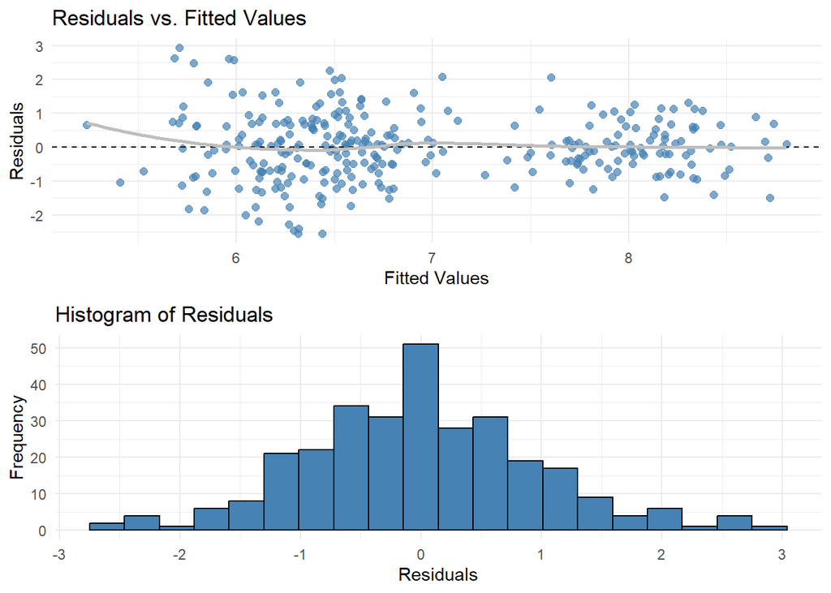

```r
# Extract fitted values and residuals
fitted_values2 <- fitted(m.cs.multiple)
residuals_values2 <- residuals(m.cs.multiple)

# Create a data frame
residuals_df2 <- data.frame(Fitted = fitted_values2, Residuals = residuals_values2)

# Create the ggplot
resid_plot2 <- ggplot(residuals_df2, aes(x = Fitted, y = Residuals)) +
               geom_point(color = "steelblue", size = 2, alpha = 0.7) +
               geom_hline(yintercept = 0, linetype = "dashed", color = "black") +
               geom_smooth(method = "loess", color = "grey", se = FALSE, linetype = "solid", size = 1) +
               labs(title = "Residuals vs. Fitted Values",
                    x = "Fitted Values", y = "Residuals") +
               theme_minimal()

# Create a histogram of residuals
resid_histogram2 <- ggplot(data.frame(residuals_values2)) +
  geom_histogram(aes(x = residuals_values2), fill = "steelblue", bins = 20, colour = "black") +
  labs(x = "Residuals", y = "Frequency", title = "Histogram of Residuals") +
  theme_minimal()

grid.arrange(resid_plot2, resid_histogram2, nrow = 2)
```

We observe no obvious patterns in the residual plot, and the residuals appear to be fairly normally distributed, which suggests a linear relationship.

**Note:** It must once again be noted that the variables are interpreted differently. We have both continuous and factor-variables. Also the ranges from the continuous variables are different e.g. staff satisfaction (probably) from 1-10 and delivery time with bigger values. Therefore for example, a +1 change in the staff satisfaction score has to be reviewed differently than a +1 change in delivery time.

Due to these **possible dependencies** between the predictor variables, it is necessary to check for multicollinearity. To do this, we calculate the Variance Inflation Factor scores (VIFs) to identify strong collinearity in our regression model, which could make the results unreliable.

```r
# Check for multicollinearity
vif(m.cs.multiple)
```

```
##                        GVIF Df GVIF^(1/(2*Df))
## staff.satisfaction 1.273317  1        1.128414
## delivery.time      1.039410  1        1.019515
## SES_category       1.317221  2        1.071309
```

The output shows that there is no severe data-based multicollinearity (All scores are clearly below the cut-off point of 5). Therefore, we do not need to undertake any correction (e.g. exclusion of a predictor variable).

### Company Analysis Request: Effect of Delivery Times on Customer Satisfaction and Interaction Effect with SES Store Sizes

In the following, two multiple regression models are illustrated: One with an interaction term between SES_category and delivery.time **without** staff.satisfaction as a covariate, and the other with an interaction term between SES_category and delivery.time, **including** staff.satisfaction as a covariate.

**Multiple Regression with an interaction term between SES_category and delivery.time WITHOUT staff.satisfaction as covariate**

```r
# Multiple Regression with interaction term (SES_category * delivery.time)
m.cs.multiple.ses.del.time <- lm(customer.satisfaction ~ SES_category * delivery.time, data = cust_satisfaction)
summary(m.cs.multiple.ses.del.time)
```

```
##
## Call:
## lm(formula = customer.satisfaction ~ SES_category * delivery.time,
##     data = cust_satisfaction)
##
## Residuals:
##      Min       1Q   Median       3Q      Max
## -2.43290 -0.63000  0.00057  0.72673  2.52903
##
## Coefficients:
##                                   Estimate Std. Error t value             Pr(>|t|)
## (Intercept)                       6.498601   0.522291  12.443 < 0.0000000000000002 ***
## SES_categoryMedium                2.418677   0.727364   3.325             0.000995 ***
## SES_categoryHigh                  2.122323   0.774569   2.740             0.006519 **
## delivery.time                    -0.004944   0.008224  -0.601             0.548142
## SES_categoryMedium:delivery.time -0.010389   0.011991  -0.866             0.386954
## SES_categoryHigh:delivery.time   -0.029762   0.012535  -2.374             0.018221 *
## ---
## Signif. codes:  0 '***' 0.001 '**' 0.01 '*' 0.05 '.' 0.1 ' ' 1
##
## Residual standard error: 0.9916 on 294 degrees of freedom
## Multiple R-squared:  0.4205, Adjusted R-squared:  0.4107
## F-statistic: 42.67 on 5 and 294 DF,  p-value: < 0.00000000000000022
```

```r
cbind(coef(m.cs.multiple.ses.del.time), confint(m.cs.multiple.ses.del.time))
```

```
##                                                     2.5 %       97.5 %
## (Intercept)                       6.498601496  5.47069931  7.526503687
## SES_categoryMedium                2.418676989  0.98717631  3.850177673
## SES_categoryHigh                  2.122323167  0.59792116  3.646725172
## delivery.time                    -0.004944435 -0.02112920  0.011240329
## SES_categoryMedium:delivery.time -0.010389343 -0.03398802  0.013209335
## SES_categoryHigh:delivery.time   -0.029761829 -0.05443078 -0.005092879
```

- The positive main effects for SES-Category at the Medium and High levels, in comparison to the reference level Low, are statistically significant (Medium: $b = 2.4187$, $CI = [0.9872, 3.8502]$, $t(294)=3.325$, $p=0.0010$; High: $b = 2.1223$, $CI = [0.5979, 3.6467]$, $t(294)=2.740$, $p=0.0065$). *It is important to note that these effects are evaluated with delivery time fixed at 0 due to the presence of interaction terms (Note: This is not particularly meaningful, as the straight line is simply drawn straight through back to the x-axis point 0.* However, we have no delivery times below ~33).
- The main effect of delivery time itself is not statistically significant ($b = -0.0049$, $CI = [-0.0211, 0.0112]$, $t(294)=-0.601$, $p=0.5481$). This result refers to the reference level of SES_category “Low”, indicating that changes in delivery time at low SES-stores do not have a clear impact on customer satisfaction.

Next, we consider the interaction terms:

- **SES_categoryMedium:delivery.time** is not statistically significant ($b = -0.0104$, $CI = [-0.0340, 0.0132]$, $t(294)=-0.866$, $p=0.3870$). This means that the effect of delivery time for Medium SES-stores does not differ notably from its effect in Low SES-stores.
- **SES_categoryHigh:delivery.time** is statistically significant ($b = -0.0298$, $CI = [-0.0544, -0.0051]$, $t(294)=-2.374$, $p=0.0182$). This indicates that changes in delivery time for High SES-stores have a more negative effect on customer satisfaction compared to the reference level Low SES-stores (which is also, as seen before, very similar to Medium SES-stores).

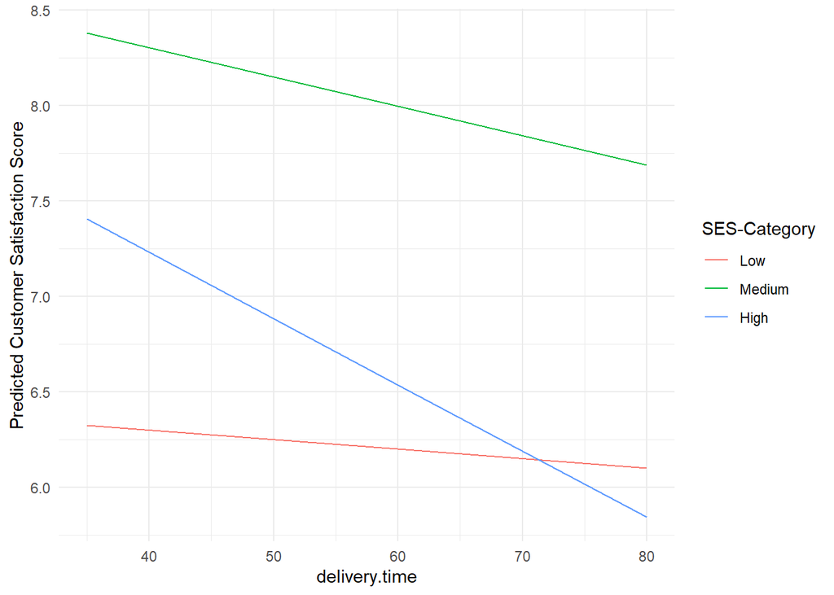

```r
# Visualisation:
score.preds <- tibble(delivery.time = rep(c(35, 60, 80), each = 3),
                      SES_category = rep(c("Low", "Medium", "High"), times = 3))

score.preds <- mutate(score.preds, score.hat = predict(m.cs.multiple.ses.del.time, score.preds))

score.preds$SES_category <- factor(score.preds$SES_category, levels = c("Low", "Medium", "High"))

ggplot(score.preds) + geom_line(aes(x = delivery.time, y = score.hat, colour = as.factor(SES_category))) +
                      labs(colour = "SES-Category") + ylab("Predicted Customer Satisfaction Score") +
                      theme_minimal()
```

As evaluated above, both the low and medium categories show a weaker negative influence on customer satisfaction compared to the high category, which has a significantly stronger negative impact when delivery time increases.

**Multiple Regression with an interaction term between SES_category and delivery.time WITH staff.satisfaction as covariate**

We could also add staff.satisfaction as covariate (another independent variable that allows the model to account for / control for the effect of staff.satisfaction).

```r
# New multiple regression model - Controling for staff.satisfaction
m.cs.multiple.ses.del.time_new <- lm(customer.satisfaction ~ SES_category * delivery.time + staff.satisfaction, data = cust_satisfaction)
summary(m.cs.multiple.ses.del.time_new)
```

```
##
## Call:
## lm(formula = customer.satisfaction ~ SES_category * delivery.time +
##     staff.satisfaction, data = cust_satisfaction)
##
## Residuals:
##      Min       1Q   Median       3Q      Max
## -2.64633 -0.63776 -0.01014  0.63099  2.75910
##
## Coefficients:
##                                   Estimate Std. Error t value     Pr(>|t|)
## (Intercept)                       4.124622   0.727432   5.670 0.0000000342 ***
## SES_categoryMedium                2.229583   0.705485   3.160      0.00174 **
## SES_categoryHigh                  2.199262   0.750151   2.932      0.00364 **
## delivery.time                    -0.004109   0.007965  -0.516      0.60632
## staff.satisfaction                0.362204   0.079781   4.540 0.0000082239 ***
## SES_categoryMedium:delivery.time -0.012360   0.011618  -1.064      0.28826
## SES_categoryHigh:delivery.time   -0.032099   0.012147  -2.643      0.00867 **
## ---
## Signif. codes:  0 '***' 0.001 '**' 0.01 '*' 0.05 '.' 0.1 ' ' 1
##
## Residual standard error: 0.9601 on 293 degrees of freedom
## Multiple R-squared:  0.4586, Adjusted R-squared:  0.4475
## F-statistic: 41.37 on 6 and 293 DF,  p-value: < 0.00000000000000022
```

```r
cbind(coef(m.cs.multiple.ses.del.time_new), confint(m.cs.multiple.ses.del.time_new))
```

```
##                                                     2.5 %       97.5 %
## (Intercept)                       4.124621946  2.69296788  5.556276016
## SES_categoryMedium                2.229583099  0.84112258  3.618043615
## SES_categoryHigh                  2.199261554  0.72289519  3.675627918
## delivery.time                    -0.004108865 -0.01978381  0.011566084
## staff.satisfaction                0.362204432  0.20518828  0.519220581
## SES_categoryMedium:delivery.time -0.012360135 -0.03522533  0.010505055
## SES_categoryHigh:delivery.time   -0.032099338 -0.05600633 -0.008192348
```

The interpretation of the new output would look as follows:

- The positive main effects for SES-Category at the Medium and High levels, in comparison to the reference level Low, are statistically significant (Medium: $b = 2.2296$, $CI = [0.8411, 3.6180]$, $t(293)=3.160$, $p=0.0017$; High: $b = 2.1993$, $CI = [0.7229, 3.6756]$, $t(293)=2.932$, $p=0.0036$). *It is important to note that these effects are evaluated with staff satisfaction kept constant and delivery time fixed at 0 due to the presence of interaction terms (Note: This is not particularly meaningful, as the straight line is simply drawn straight through back to the x-axis point 0. However, we have no delivery times below ~33).*
- The main effect of delivery time itself is not statistically significant ($b = -0.0041$, $CI = [-0.0198, 0.0116]$, $t(293)=-0.516$, $p=0.6063$). This result refers to the reference level of SES_category “Low”, indicating that changes in delivery time at low SES-stores do not have a clear impact on customer satisfaction.
- There is a significant positive effect of staff satisfaction on customer satisfaction ($t(293)=4.540$, $p<0.0001$), with every 1-point increase in staff satisfaction predicting an average increase of 0.3622 points in customer satisfaction ($CI = [0.2052, 0.5192]$).

Interaction terms:

- **SES_categoryMedium:delivery.time** is not statistically significant ($b = -0.0124$, $CI = [-0.0352, 0.0105]$, $t(293)=-1.064$, $p=0.2883$). This means that the effect of delivery time for Medium SES-stores does not differ notably from its effect in Low SES-stores.
- **SES_categoryHigh:delivery.time** is statistically significant ($b = -0.0321$, $CI = [-0.0560, -0.0082]$, $t(293)=-2.643$, $p=0.0087$). This indicates that changes in delivery time for High SES-stores have a more negative effect on customer satisfaction compared to the reference level Low SES-stores (which is also, as seen before, very similar to Medium SES-stores).

If we now want to make predictions, we have to specify a value for the staff.satisfaction (which is kept constant, here for example 6 or 8). We can see that the slope of the influence of the delivery time does not change as a result, the straight lines simply move parallel to each other.

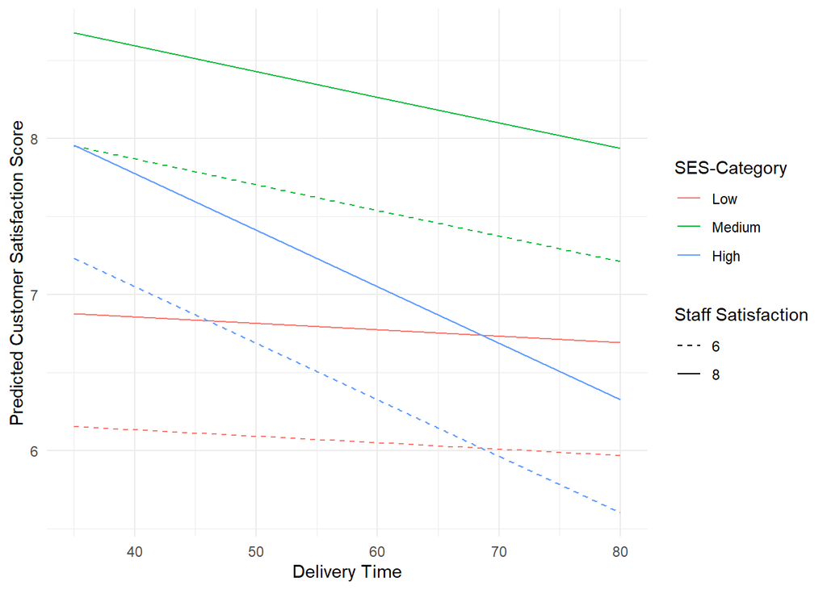

```r
score.preds <- tibble(
  delivery.time = rep(c(35, 60, 80), times = 6),
  SES_category = rep(c("Low", "Medium", "High"), each = 3, times = 2),
  staff.satisfaction = rep(c(6, 8), each = 9))  # Two groups: staff.satisfaction = 6 und 8

score.preds <- mutate(score.preds, score.hat = predict(m.cs.multiple.ses.del.time_new, score.preds))

score.preds$SES_category <- factor(score.preds$SES_category, levels = c("Low", "Medium", "High"))

ggplot(score.preds) +
  geom_line(aes(x = delivery.time, y = score.hat,
                colour = SES_category, linetype = factor(staff.satisfaction))) +
  labs(colour = "SES-Category", linetype = "Staff Satisfaction",
       y = "Predicted Customer Satisfaction Score",
       x = "Delivery Time") +
  scale_linetype_manual(values = c("8" = "solid", "6" = "dashed")) +
  theme_minimal()
```

## Conclusion

The analysis resulted in a number of important findings, which are listed below:

- The differences between stores with and without new range products were not statistically significant. As a result, this variable was excluded from further analysis.
- The variable staff.satisfaction was strongly positively correlated with customer satisfaction, while delivery time showed a negative correlation. Furthermore, both variables were statistically significant in explaining and predicting customer satisfaction scores, with staff satisfaction demonstrating slightly stronger explanatory power, as indicated by the standardised coefficient.
- The SES-category variable added explanatory and predictive power, showing significant differences between all category pairs (especially low - medium and medium - high, but also low - high) in our analysis.
- Through a VIF test, we concluded that there is no evidence of data-based multicollinearity among our variables. Therefore, it was not necessary to make any corrections, such as excluding predictor variables.
- An interaction term between delivery time and SES-category revealed a significant effect, particularly for High SES-stores compared to the reference level Low. The analysis showed that delivery time had a stronger negative effect on customer satisfaction for High SES-stores compared to the reference category Low SES-stores. For medium SES-stores, changes in delivery time did not have a significantly stronger effect on customer satisfaction compared to Low SES-stores. These results were consistent both with and without controlling for staff satisfaction as covariate.